# Chapter 5 - Foundations for Inference

**Heights of adults.** (7.7, p. 260) Researchers studying anthropometry collected body girth measurements and skeletal diameter measurements, as well as age, weight, height and gender, for 507 physically active individuals. The histogram below shows the sample distribution of heights in centimeters.

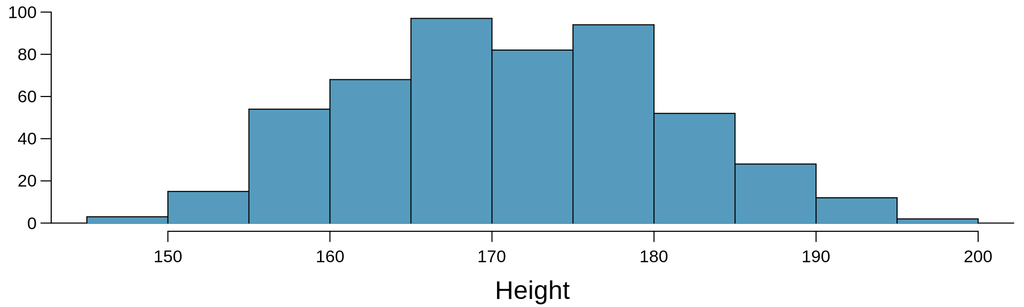

1. What is the point estimate for the average height of active individuals? What about the median?

```r
summary(bdims$hgt)
```

```
##    Min. 1st Qu.  Median    Mean 3rd Qu.    Max.
##   147.2   163.8   170.3   171.1   177.8   198.1
```

JR Answer: the average height is 171.1 and the median is 170.3

2. What is the point estimate for the standard deviation of the heights of active individuals? What about the IQR?

```r
sd(bdims$hgt)
```

```
## [1] 9.407205
```

```r
IQR <- 177.8-163.8
IQR
```

```
## [1] 14
```

JR Answer: The point estimate is 9.41 and the point estimate for the IQR is 14

3. Is a person who is 1m 80cm (180 cm) tall considered unusually tall? And is a person who is 1m 55cm (155cm) considered unusually short? Explain your reasoning.

```r
tall2sd <- mean(bdims$hgt) + 2*(sd(bdims$hgt))
tall2sd
```

```
## [1] 189.9582
```

```r
short2sd <- mean(bdims$hgt) - 2*(sd(bdims$hgt))
short2sd
```

```
## [1] 152.3294
```

Both are not considered to0 tall or too short as they fall within the 95% conf. intervals. If he/she was taller then 189.96 they would be tall. If he/she was shorter then 152.33 they would be considered too short.

4. The researchers take another random sample of physically active individuals. Would you expect the mean and the standard deviation of this new sample to be the ones given above? Explain your reasoning.

JR Answer: I would expect that mean and SD to be be similiar but not exact as this is a random sample. It would really depend on if more outliers were to be part of the sample if it would deviate much from the total population.

5. The sample means obtained are point estimates for the mean height of all active individuals, if the sample of individuals is equivalent to a simple random sample. What measure do we use to quantify the variability of such an estimate (Hint: recall that $SD_x = \frac{\sigma}{\sqrt{n}}$)? Compute this quantity using the data from the original sample under the condition that the data are a simple random sample.

```r
n <- 507
SE_hgt <- sd(bdims$hgt)/sqrt(n)
SE_hgt
```

```
## [1] 0.4177887
```

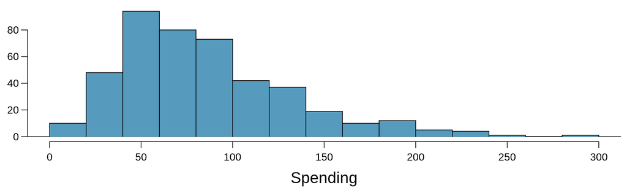

```r
Linterval <- 80.31
Uinterval <- 89.11
SE <- (Uinterval - Linterval)/2
SE
```

```
## [1] 4.4
```

True. CI of 95% is a margin of error is 4.4

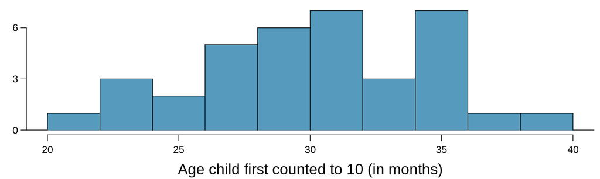

1. Are conditions for inference satisfied? JR Answer: Yes - Random and independant and sample >30
2. Suppose you read online that children first count to 10 successfully when they are 32 months old, on average. Perform a hypothesis test to evaluate if these data provide convincing evidence that the average age at which gifted children fist count to 10 successfully is less than the general average of 32 months. Use a significance level of 0.10. JR Answer:

```r
mean <- 30.69
n <- 36
sd <- 4.31
x <- 32
se <- sd / sqrt(n)
Z_score <- (mean - x) / se
p <- pnorm(Z_score, mean = 0, sd = 1)
p
```

```
## [1] 0.0341013
```

3. Interpret the p-value in context of the hypothesis test and the data. JR Answer: Since P value is .03 which is less then the sign. level of .10 , the hypothesis in not correct that the average age of Gifted children first count to 10 is the same as general average.
4. Calculate a 90% confidence interval for the average age at which gifted children first count to 10 successfully. JR Answer:

```r
lower <- mean - 1.645 * se
upper <- mean + 1.645 * se
c(lower, upper)
```

```
## [1] 29.50834 31.87166
```

5. Do your results from the hypothesis test and the confidence interval agree? Explain. JR Answer:

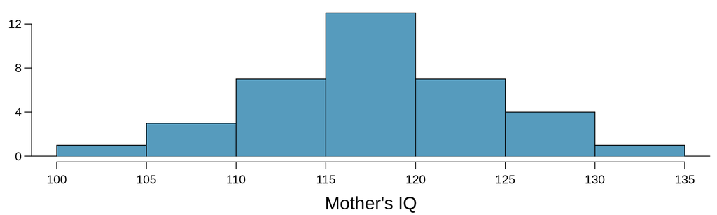

**CLT.** Define the term “sampling distribution” of the mean, and describe how the shape, center, and spread of the sampling distribution of the mean change as sample size increases.

**CFLBs.** A manufacturer of compact fluorescent light bulbs advertises that the distribution of the lifespans of these light bulbs is nearly normal with a mean of 9,000 hours and a standard deviation of 1,000 hours.

1. What is the probability that a randomly chosen light bulb lasts more than 10,500 hours?
2. Describe the distribution of the mean lifespan of 15 light bulbs.
3. What is the probability that the mean lifespan of 15 randomly chosen light bulbs is more than 10,500 hours?
4. Sketch the two distributions (population and sampling) on the same scale.
5. Could you estimate the probabilities from parts (a) and (c) if the lifespans of light bulbs had a skewed distribution?

**Same observation, different sample size.** Suppose you conduct a hypothesis test based on a sample where the sample size is n = 50, and arrive at a p-value of 0.08. You then refer back to your notes and discover that you made a careless mistake, the sample size should have been n = 500. Will your p-value increase, decrease, or stay the same? Explain.